# Simple choropleths in R

2015-03-16

*Note: post was originally in D3, but I rewrote because I now prefer static figures*

## Background

I’ve started this blog to help organize my thoughts relative to data science, machine learning, statistics, logic-based analysis, and various visualization tools. The focus will be on data-related tools and techniques. While I’ll keep these posts applicable to a wide (data-interested) audience, I’m sure the analysis will occasionally focus on Salt Lake City, where I’m currently based.

To kick things off, I wanted to show how easy it is to create choropleths with R and choroplethr, showing diabetes rates for each county in the US. For those who love maps and data, choropleths are the holy grail of nerd-dom. If you’re unclear on this, choropleths allow you to take a simple map and essentially lay data on top. Great, right?!

## Details

### Getting public health data

First, let’s pull 2015 county-level data (in CSV format) from [County Health Rankings](http://www.countyhealthrankings.org/rankings/data), which is a fantastic place to analyze state by geographic health differences in the US.

We pull the data into R…

```r
df <- read.csv('../data/2015 CHR Analytic Data.csv')
```

### Clean up

```r
# Remove state-summary rows
df <- df[df$COUNTYCODE != 0,]

# Grab only the columns we're interested in--CountyID and Diabetes rate
df <- df[,c("COUNTYCODE", "STATECODE", "Diabetes.Value")]

# Encode for choroplethr
df$COUNTYCODE <- as.integer(df$COUNTYCODE)

# Pad county digits
df$COUNTYCODE <- sprintf("%03d", df$COUNTYCODE)
```

### Create Proper county code

```r
# Concatenate and create FIPS
df$FIPSCODE <- as.numeric(paste0(df$STATECODE,df$COUNTYCODE))

# Reduce dataset and rename cols for county_choropleth func
df_final <- df[,c('FIPSCODE', "Diabetes.Value")]
colnames(df_final) <- c("region","value")
```

### Plot the choropleth

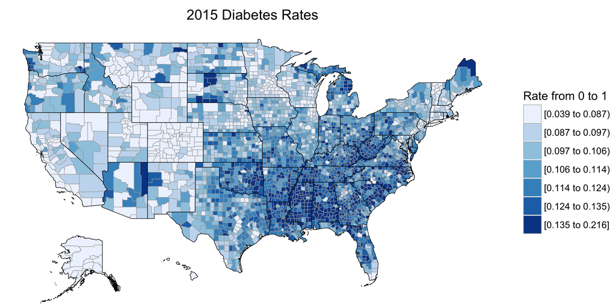

## The result

Voilà, a choropleth! Since this isn’t a post on diabetes, we can simply say that the deep south has serious issues with chronic disease.

The beautiful thing about this R package is that you can fairly quickly plot any of the awesome county-level data* you can find [here](http://www.countyhealthrankings.org/rankings/data), [here](https://www.data.gov), [here](https://www.census.gov), or [here](https://www.cdc.gov/datastatistics/index.html).

Speaking of maps, if you’re in the market for a US map for the house, you probably can’t do better than [this](http://www.imusgeographics.com/usa-maps)–it was made by one man in a [farm house in Oregon](http://www.slate.com/articles/arts/culturebox/2012/01/the_best_american_wall_map_david_imus_the_essential_geography_of_the_united_states_of_america_.html).

Note that

- The raw notebook can be found [here](https://github.com/levithatcher/hugo-blog/tree/master/content/blog)
- *Data for choropleths needs a [FIPS Code](https://en.wikipedia.org/wiki/FIPS_county_code)